# Exercise Set 7

**Instructions:**

- Do not write your name on the assignment. Be careful about any warnings that might display some file path with your name included.
- Receiving help from classmates and/or ideas from Generative AI is allowed. **However, you must submit your own original work.**
- For questions that require coding, you need to write the relevant code and display its output. Your output should either be the direct answer to the question or clearly display the answer in it.
- For questions that require a written answer (sometimes along with the code), you need to put your answer in a Markdown cell. Writing the answer as a comment or as a print line is not acceptable.
- You need to render this file as HTML using Quarto and submit the HTML file. **Please note that this is a requirement and not optional.** A submission cannot be graded until it is properly rendered.

Import all the libraries and tools you need below.

```python
import matplotlib.pyplot as plt
from sklearn.datasets import make_blobs, make_circles
from sklearn.cluster import KMeans
import numpy as np
import pandas as pd
```

Run the cell given below to create and plot two different two-dimensional datasets:

- The first dataset has four blobs that come from different Gaussian distributions. Assume that each blob is a cluster.
- The second dataset has two concentric circles centered at the origin. Assume that each circle is a cluster.

**Note:** In this exercise set and the next, you will work on these toy datasets to understand both the scikit-learn tools and Lloyd’s algorithm better. In Homework Assignment 3, you will apply clustering to real-life datasets.

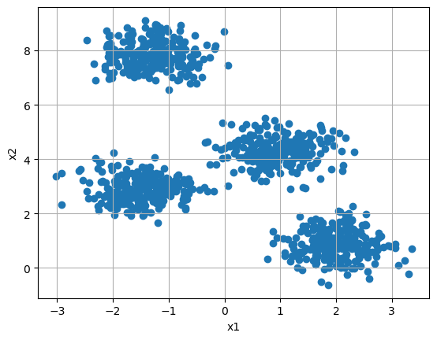

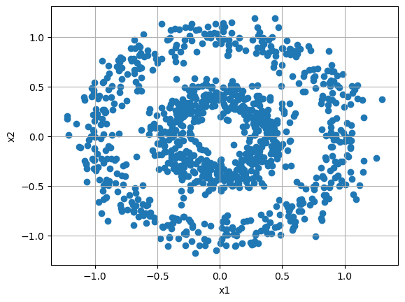

```python
n_samples = 1000
n_components = 4

X_blob, true_labels_blob = make_blobs(n_samples=n_samples, centers=4, cluster_std=0.50, random_state=0)
X_circ, true_labels_circ = make_circles(n_samples=n_samples, noise=0.1, random_state=0,factor=0.4)

plt.scatter(X_blob[:,0],X_blob[:,1])
plt.grid()
plt.xlabel('x1')
plt.ylabel('x2')
plt.show()

plt.scatter(X_circ[:,0],X_circ[:,1])
plt.grid()
plt.xlabel('x1')
plt.ylabel('x2')
plt.show()
```

## 1)

Create and train two [K-Means](https://scikit-learn.org/1.5/modules/generated/sklearn.cluster.KMeans.html) models, one for each dataset. For both models, use `random_state=1` for reproducible initialization. Note that you need to pick a proper `n_clusters`. Leave the other inputs default. **(10 points)**

```python
kmeans_blob = KMeans(n_clusters=4, random_state=1)
kmeans_circ = KMeans(n_clusters=2, random_state=1)

kmeans_blob.fit(X_blob)
kmeans_circ.fit(X_circ)
```

```
KMeans(n_clusters=2, random_state=1)
```

## 2)

Using the trained models, obtain the predicted cluster labels. Plot both datasets again, only this time, color code the observations with the **predicted** labels.

**Note:** If you are not familiar with data visualization in Python, the lines in the given cell above should be helpful. Just keep in mind that `plt.scatter` function has a `c` input for color-coding.

**(10 points)**

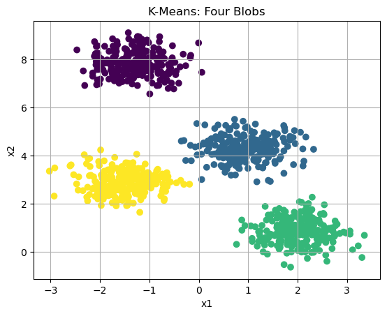

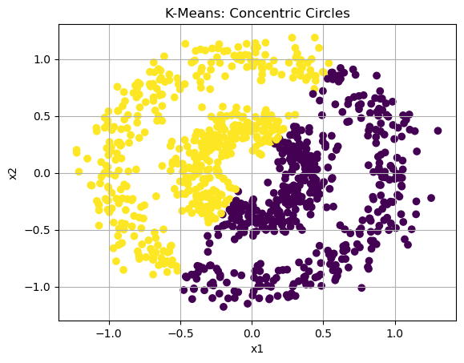

```python
pred_labels_blob = kmeans_blob.labels_
pred_labels_circ = kmeans_circ.labels_

plt.scatter(X_blob[:, 0], X_blob[:, 1], c=pred_labels_blob)
plt.grid()
plt.xlabel('x1')
plt.ylabel('x2')
plt.title('K-Means: Four Blobs')
plt.show()

plt.scatter(X_circ[:, 0], X_circ[:, 1], c=pred_labels_circ)
plt.grid()
plt.xlabel('x1')
plt.ylabel('x2')
plt.title('K-Means: Concentric Circles')
plt.show()
```

## 3)

Does the K-Means model properly find the clusters in both datasets? Does it fail in any dataset? Why or why not? **Your explanation should include the assumptions behind a K-Means model for credit.** **(10 points)**

No, for the first dataset K-Means properly finds the clusters but for the second data set it fails to do so. This happens because K-Means works better when the clusters are roughly circular and separated from each other. In the first dataset, the four groups are clearly separated, so K-Means can identify them. But in the second dataset, the two clusters are concentric cirles. Since K-Means assigns points based on their distance to the centroids, it divides the regions instead of separating both circles, showing that K-Means doesn’t work well with clusters that have more complex shapes.

## 4)

In this question, you will write the two functions that implement Lloyd’s algorithm. You will bring them together in the next exercise set.

### a)

Define a function called `update_step`. It should take two inputs: (1) `X`, the variable matrix and (2) `cluster_preds`, the vector of predicted cluster labels.

For each unique cluster label, the function should calculate the centroid by taking variable averages.

The function should return the calculated centroid values for each unique cluster label, **as a two-dimensional numpy array**. The size of the array should be: **(number of unique cluster labels, number of variables).**

**You are not allowed to use loops/comprehensions.** The implementation should be vectorized. Consider the following steps: - Concatenate X and the labels and convert the output to a DataFrame. - [Group by](https://pandas.pydata.org/docs/reference/api/pandas.DataFrame.groupby.html) the last column. - Return the group averages, converted back to a numpy array.

**(30 points)**

```python
def update_step(X, cluster_preds):
    df = pd.DataFrame(np.column_stack((X, cluster_preds)))
    centroids = df.groupby(X.shape[1]).mean()
    return centroids.to_numpy()


toy_X = np.arange(1,37).reshape(9,4)
toy_labels = np.array([0,1,2,0,1,2,0,1,2])

update_step(toy_X, toy_labels)

# should return:

#array([[13., 14., 15., 16.],
#       [17., 18., 19., 20.],
#       [21., 22., 23., 24.]])
```

```
array([[13., 14., 15., 16.],
       [17., 18., 19., 20.],
       [21., 22., 23., 24.]])
```

### b)

Define a function called `assignment_step`. It should take two inputs: (1) `X`, the variable matrix and (2) `centroids`, the matrix of predicted centroids.

For each observation, the function should calculate the cluster label by finding the closest centroid. The function should return the predicted cluster labels for each observation, **as a one-dimensional numpy array**. The size of the array should be: **(number of observations, )**.

**You are not allowed to use loops/comprehensions.** The implementation should be vectorized. Consider the following steps: - Convert X to a DataFrame. - To each row, [apply](https://pandas.pydata.org/docs/reference/api/pandas.DataFrame.groupby.html) a function that finds the Euclidean distance to each row of `centroids` and returns the row index with the smallest distance. (You can implement this with a lambda function or define another function.) - Convert the output to a numpy array.

**(40 points)**

```python
def assignment_step(X, centroids):
    distances = np.linalg.norm(X[:, None, :] - centroids[None, :, :], axis=2)
    return np.argmin(distances, axis=1)

toy_X = np.arange(1,37).reshape(9,4)
toy_centroids = np.array([[13., 14., 15., 16.],
                           [17., 18., 19., 20.],
                           [21., 22., 23., 24.]])

assignment_step(toy_X, toy_centroids)

# should return:
    # array([0, 0, 0, 0, 1, 2, 2, 2, 2]
```

```
array([0, 0, 0, 0, 1, 2, 2, 2, 2])
```